# Data cleaning and exploration with speciesgeocodeR

Alexander Zizka

2015-07-02

# Introduction

SpeciesgeocodeR is an R-package for the exploration, cleaning and preparation of large scale species distribution data for biogeographic and macro-evolutionary analyses. The package provides functions for the automated cleaning of geographic data from public databases, the fast and reproducible classification of point occurrences to geographic areas (including elevation thresholds and output in nexus format) as well functions to explore the occurrence data to facilitate data-cleaning and interpretation. This includes automated summary statistics and maps and the calculation and vizualization of coexistence matrices, species richness patterns and species ranges. The package is especially designed for R-beginners and can provide informative output directly from text files with on single command. SpeciesgeocodeR has particularly been tested for global scale data sets.

## Features of the package

- automated cleaning of geographic data sets
- classification of point occurrences to geographic areas for large datasets
- inclusion of multiple elevation thresholds and a minimum occurrence threshold into the classification
- output as nexus file
- summary statistics and -maps
- easy-to-use wrapper function
- coexistence matrix calculation
- species richness maps
- batch calculation of species ranges and range sizes

# Example data

We will use distribution data of Madagascan Lemur species and a simplified version of the WWF biomes of Madagascar as examples in this tutorial. The data are distributed in R data format or as .txt files with the package. Use `data(package = "speciesgeocodeR")` to see all example dataset distributed with the package. Most functions of speciesgeocodeR can accept file paths as arguments. The following lines of code will load the example occurrences and areas, and store them in R objects called “lemurs” and “mdg_poly”.

```r
#occurrences
data(lemurs)

#areas
data(mdg_poly)
```

You can load your own data from text or shape files by replacing the “system.file(”extdata“,”lemurs.txt“, package =”speciesgeocodeR“)” or “system.file(”extdata“,”mdg_biomes_simple.txt“, package =”speciesgeocodeR“)” in the next example by the path to your input files.

```r
#occurrences
occ <- read.table(system.file("extdata","lemurs.txt", package = "speciesgeocodeR"), row.names = NULL)

#areas
pol <- read.table(system.file("extdata","mdg_biomes_simple.txt", package = "speciesgeocodeR"), row.names = NULL)
```

# Automated cleaning of geographic data

The `GeoClean` function can be used to check geographic occurrence data for coordinate integrity and to flag a set of potential problems that are known to occur with data from public databases. Load the data from a .txt file with three obligatory columns, named “identifier” (species name, each line one occurrence), “XCOOR” (decimal longitude) and “YCOOR” (decimal latitude) and an optional country column for more complex tests:

```
##           identifier    XCOOR    YCOOR country
## 1 Cheirogaleus major 47.41047 -21.2649     MDG
## 2 Cheirogaleus major 49.09200 -18.0480     MDG
## 3 Cheirogaleus major 48.46700 -18.7020     MDG
## 4 Cheirogaleus major 48.42700 -18.7920     MDG
## 5 Cheirogaleus major 48.81300 -18.6950     MDG
## 6 Cheirogaleus major 48.57800 -18.1980     MDG
```

We will test the function on the lemurs_test dataset, which deliberately includes problematic coordinates. We will first perform some simple test for coordinate validity. Each argument of `GeoClean` represents one test, see `?GeoClean` for details.

```r
data(lemurs_test)

#A vector FALSE if one of the test failed"
tt <- GeoClean(lemurs_test, isna = TRUE, isnumeric = TRUE, coordinatevalidity = TRUE,
               containszero = TRUE, zerozero = TRUE, zerozerothresh = 1, latequallong = TRUE)

#Alternatively a dataframe with results from each test
tt.long <- GeoClean(lemurs_test, isna = TRUE, isnumeric = TRUE, coordinatevalidity = TRUE,
                    containszero = TRUE, zerozero = TRUE, zerozerothresh = 1,
                    latequallong = TRUE, verbose = TRUE)

simple.clean <- subset(lemurs_test, tt == TRUE)
```

When the coordinates are all valid, more complex tests can be performed. For example, if points fall within the country indicated in the country column, if the points have been assigned to country centroid or the country capital, or if the points have been assigned to the GBIF headquarters.

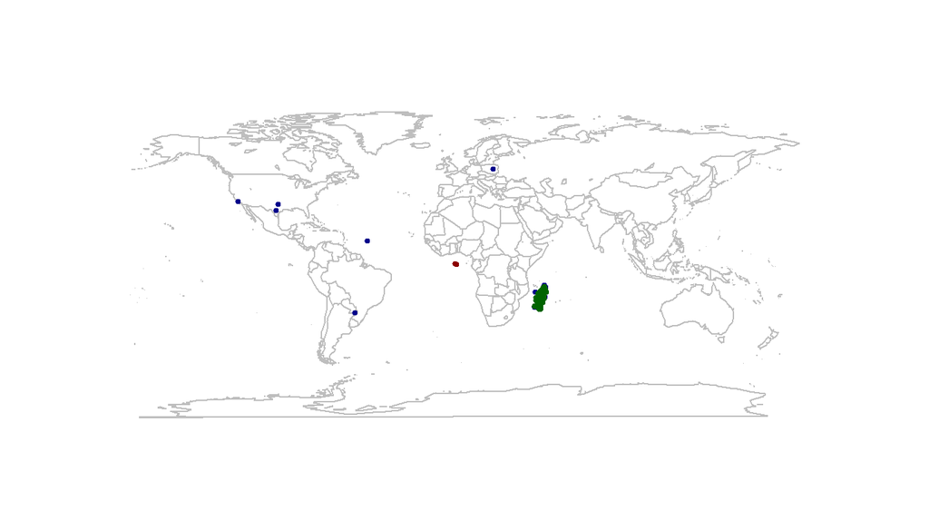

```r
library(maptools)

data(countryref)
data(wrld_simpl)

tt2 <- GeoClean(simple.clean, capitalcoords = TRUE, countrycheck = TRUE,
                polygons = wrld_simpl, GBIFhead = TRUE, countrycentroid = TRUE,
                referencecountries = countryref, capthresh = 0.5, contthresh = 0.5)
complex.clean <- subset(simple.clean, tt2 == TRUE)

map("world", col = "grey")
points(lemurs_test$XCOOR, lemurs_test$YCOOR, col = "darkred", pch = 20, cex = .7)
points(simple.clean$XCOOR, simple.clean$YCOOR, col = "darkblue", pch = 20, cex = .7)
points(complex.clean$XCOOR, complex.clean$YCOOR, col = "darkgreen", pch = 20, cex = .7)
```

# Classifying species to areas

## Input data format

SpeciesgeocodeR can use different input formats.

### 1. Occurrences and areas as .txt files

Provide occurrences and areas as .txt files in the working directory. The files needs three obligatory columns named “identifier” (species name, each line one occurrence), “XCOOR” (decimal longitude) and “YCOOR” (decimal latitude) for the occurrence file. The area file can be provided in a similar style: “identifier” (polygon name, each line is one vertex), “XCOOR” (decimal longitude) and “YCOOR” (decimal latitude). To load your data from text files replace the “system.file(”extdata“,”lemurs.txt“, package =”speciesgeocodeR“)” or “system.file(”extdata“,”mdg_biomes_simple.txt“, package =”speciesgeocodeR“)” in the next examples by the path to your input files.

```
##      row.names identifier    XCOOR    YCOOR
## 1 Cheirogaleus      major 47.41047 -21.2649
## 2 Cheirogaleus      major 49.09200 -18.0480
## 3 Cheirogaleus      major 48.46700 -18.7020
## 4 Cheirogaleus      major 48.42700 -18.7920
## 5 Cheirogaleus      major 48.81300 -18.6950
## 6 Cheirogaleus      major 48.57800 -18.1980
```

```
##     identifier    XCOOR     YCOOR
## 1 Moist Forest 50.22007 -15.98834
## 2 Moist Forest 47.16053 -24.92900
## 3 Moist Forest 46.68460 -25.20096
## 4 Moist Forest 46.61661 -24.40208
## 5 Moist Forest 46.87157 -24.28310
## 6 Moist Forest 46.37865 -23.92615
```

```r
outp <- SpGeoCod(system.file("extdata","lemurs.txt", package = "speciesgeocodeR"),
                 system.file("extdata","mdg_biomes_simple.txt", package = "speciesgeocodeR"))
```

### 2. Occurrences as .txt and areas as .shp

Provide occurrences as .txt file and areas as a .shp file in the working directory. The .txt file needs three columns named “identifier” (species name, each line one occurrence), “XCOOR” (decimal longitude) and “YCOOR” (decimal latitude). You can try to use any shape file, but the name of the datacolumn naming the diffrent polygons must be indicated via the `areanames` argument.

```r
outp <- SpGeoCod(system.file("extdata","lemurs.txt", package = "speciesgeocodeR"),
                 system.file("extdata","mdg_biomes_simple.shp", package = "speciesgeocodeR"),
                 areanames = "name")
```

### 3. Occurrences as `data.frame`, areas as `spatialPolygons`

Indicate the column with the names of single polygons by the `areanames` argument. Find the respective column using the `head` function.

```r
data(lemurs)
data(mdg_biomes)

head(mdg_biomes)
```

```
##   id         name
## 0  1 Moist Forest
## 1  2   Dry Forest
## 2  3   Shrublands
```

```r
outp <- SpGeoCod(lemurs, mdg_poly, areanames = "name")
```

### 4. Occurrences from GBIF

Use GBIF occurrence data by indicating species names as input (**This will download data from the Internet**).

```r
outp <- SpGeoCod(c("Indri indri", "Lemur catta" ), pol, areanames = "name")
```

## Classifying species to areas

The `SpGeoCod` function classifies all occurrences to the respective areas and calculates summary statistics. For larger data sets this might take a moment. The results can be explored with `summary` or `plot`.

```r
outp <- SpGeoCod(lemurs, mdg_biomes, areanames = "name")

summary(outp)
```

```
## $overall
## [1] "39 species with 403 occurrence points and 3 input polygons."
##
## $species_coordinates
##      XCOOR           YCOOR
##  Min.   :43.62   Min.   :-25.00
##  1st Qu.:47.00   1st Qu.:-19.59
##  Median :48.25   Median :-18.47
##  Mean   :47.98   Mean   :-18.25
##  3rd Qu.:49.09   3rd Qu.:-15.70
##  Max.   :50.17   Max.   :-12.63
##
## $polygons
## [1] "0" "1" "2"
##
## $species_number_per_polygon
##        [,1]
## Mean     16
## Median   16
## Max      24
## Min       8
##
## $not_classified_samples
## [1] "4 occurrences did not fall in any polygon"
```

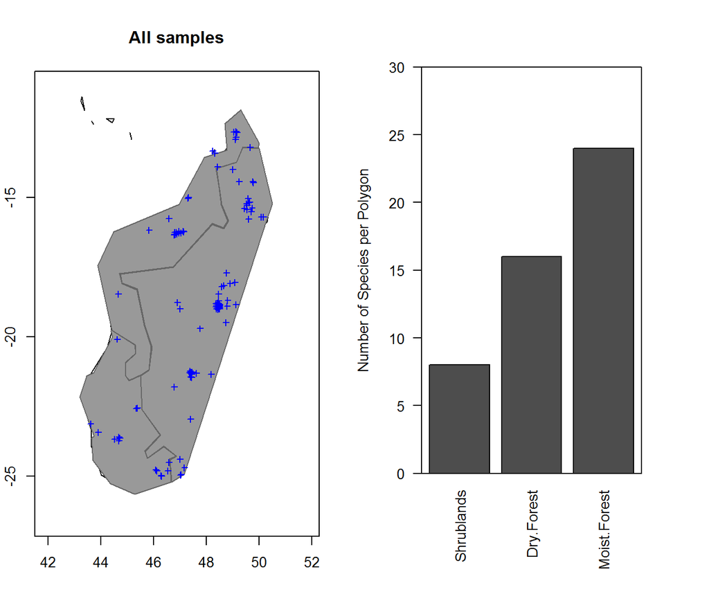

```r
plot(outp, mar = c(8,4,4,4))
```

The `plot` function can visualize multiple results, depending on the `plottype` argument, including species number per area, occurrences per species per area, occurrences per area per species or maps for each species and each area. See `?plot.spgeoOUT` for details. For example species occurrences per polygon:

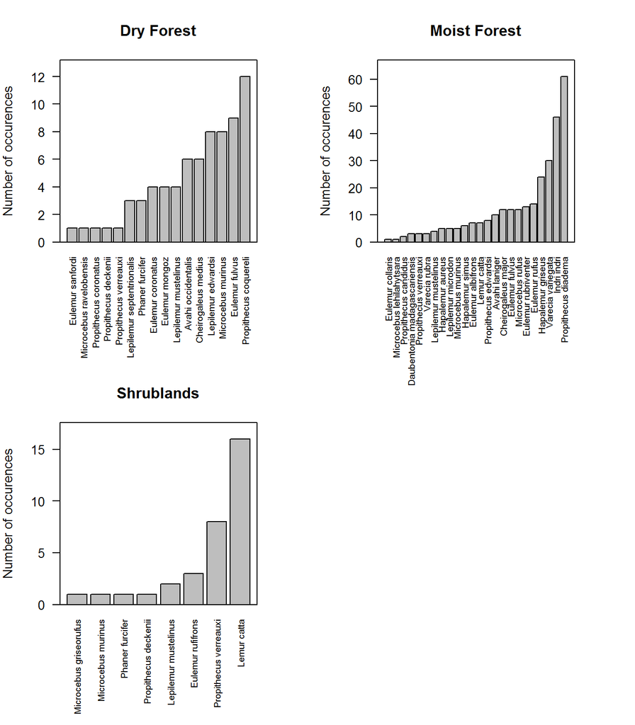

```r
par(mfrow = c(2,2), mar = c(8,4,4,4))
plot(outp, plottype = "polygons")
```

Or a map of occurrences per polygon:

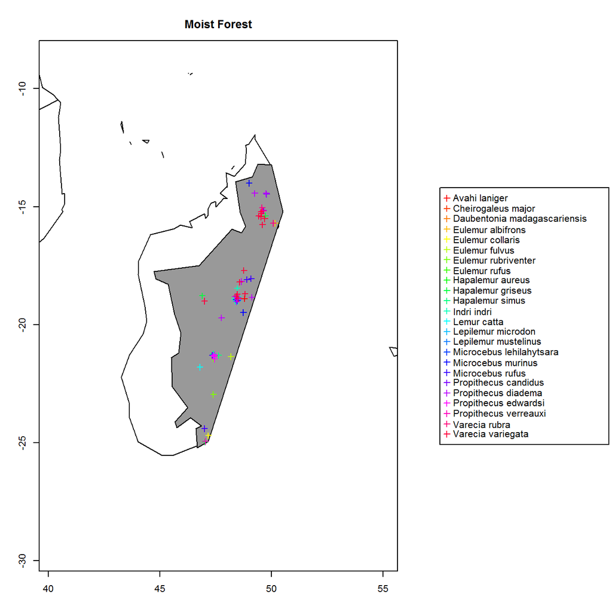

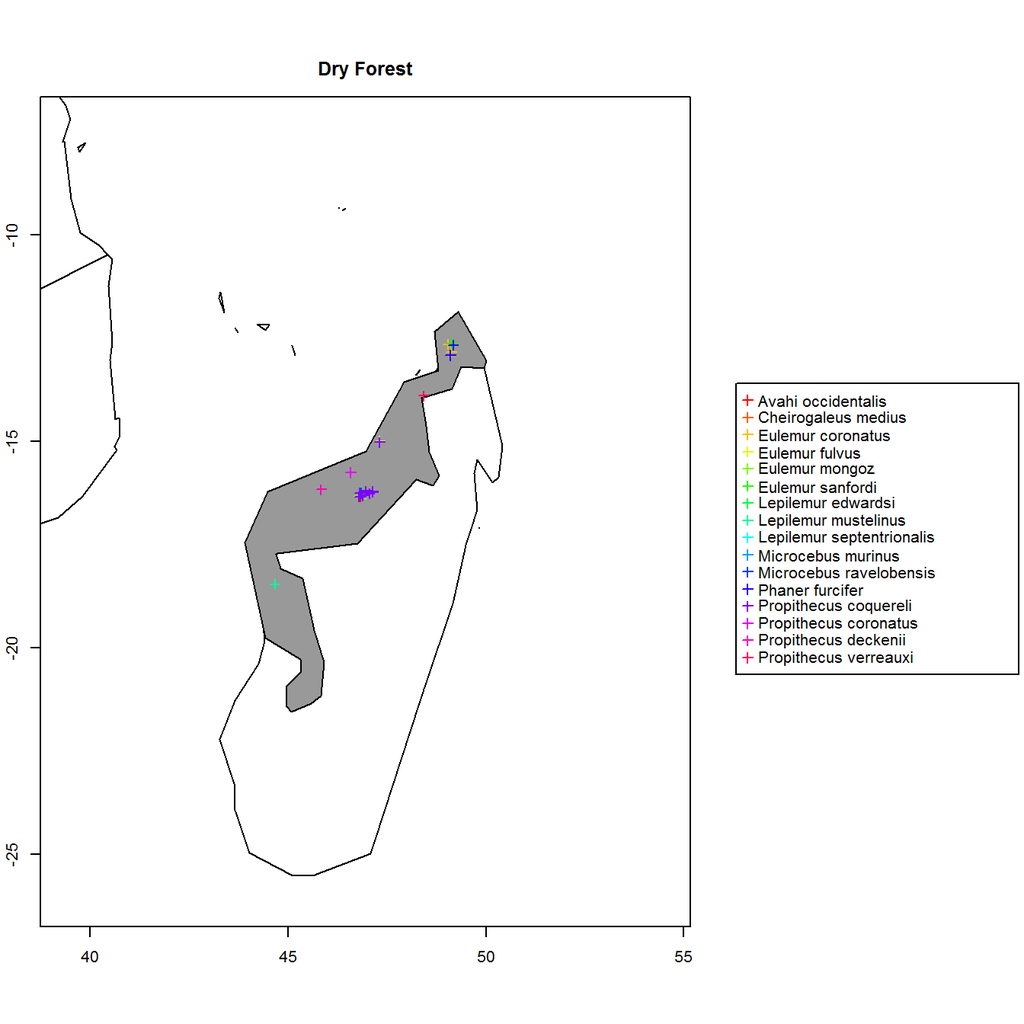

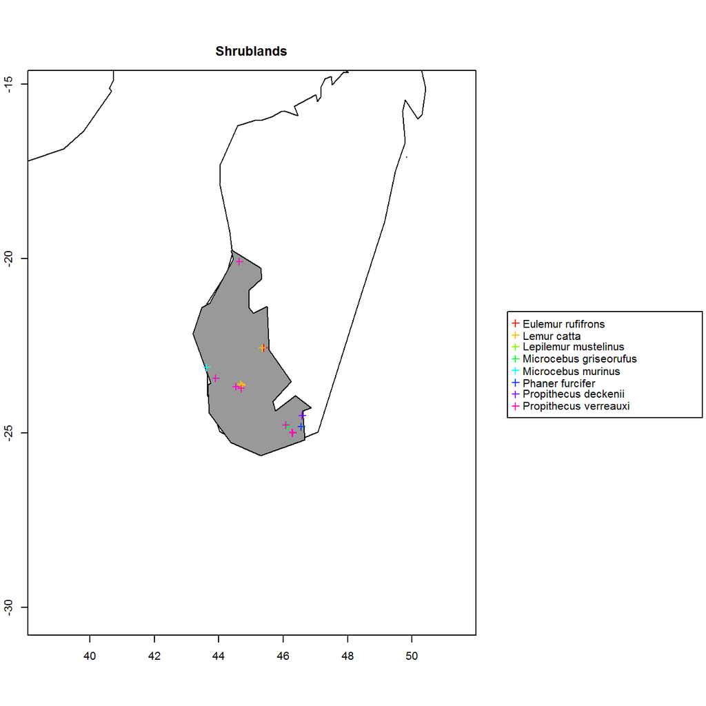

```r
par(mfrow = c(2,2), mar = c(8,4,4,4))
plot(outp, plottype = "mappolygons")
```

### Write results to the working directory.

The `WriteOut` function provides a generic way to write the results of your analysis to the working directory (tables as .txt, graphs and maps as .pdf). You can write a subset of the results using the `writetype` argument, or all results with `writetype = "all"`. See `?WriteOut` for details.

```r
WriteOut(outp, writetype = "nexus")
#WriteOut(outp, writetype = "all")
#WriteOut(outp, writetype = "graphs")
#WriteOut(outp, writetype = "statistics")
```

### SpeciesGeoCoder

The `SpeciesGeoCoder` function provides a wrapper to run a entire classification from text input.

```r
SpeciesGeoCoder(lemurs, mdg_biomes, areanames = "name")
```

# Data exploration features

### Minimum occurrence threshold

For widespread species, or if the data quality is questionable, it can be of interest to set a minimum number of occurrences that a species needs to be counted as present in a given area. The `occ.thresh` argument allows you to set a minimum percentage of occurrences. For example, we can code lemur species as present in a biome only if at least 10 percent of the occurrences of this species are in the given biome:

```r
outp <- SpGeoCod(lemurs, mdg_biomes, areanames = "name", occ.threh = 10)
```

### INcluding Elevation in the area classification

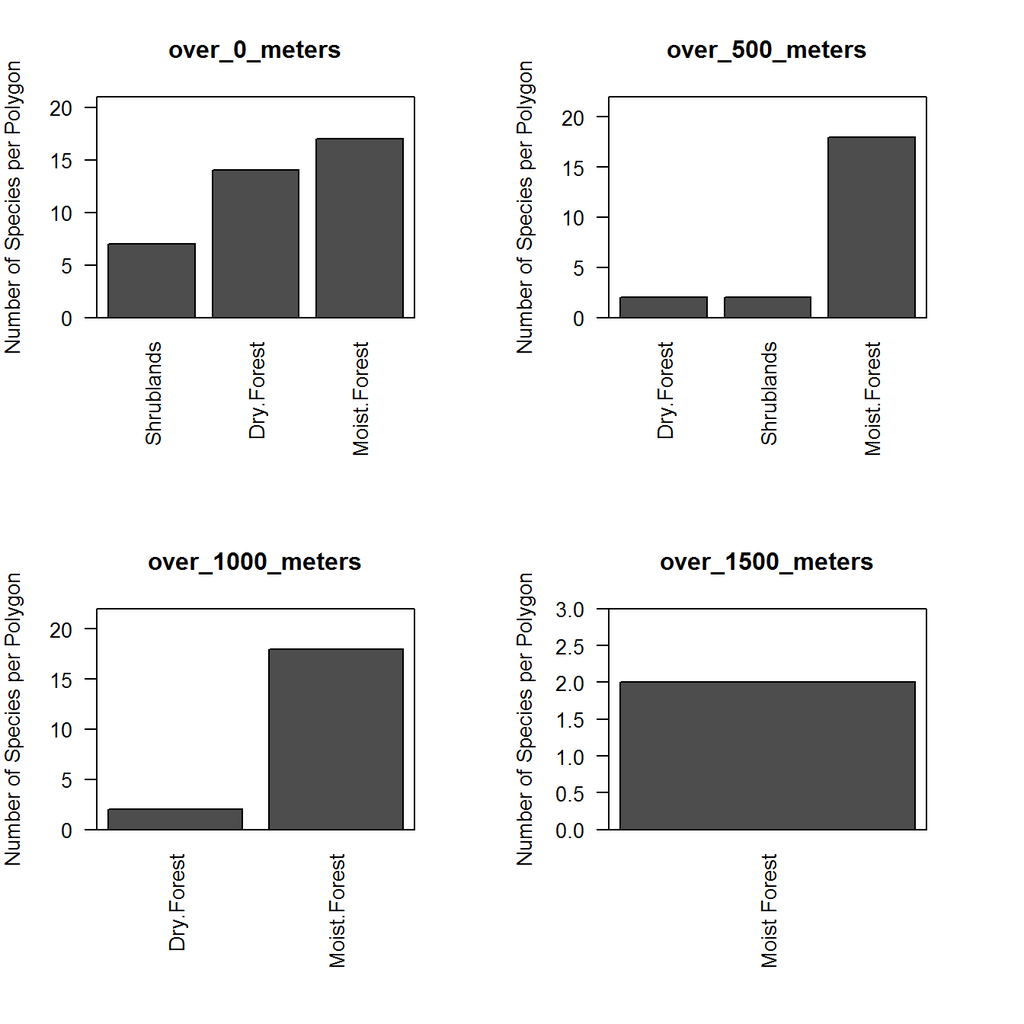

```r
outp <- SpGeoCod(lemurs, mdg_biomes, areanames = "name",
                 elevation = T, threshold = c(500, 1000, 1500))

#write to working directory
WriteOut(outp)

#plot species numbers at all elevation intervals
par(mar = c(8,4,4,4), mfrow = c(2,2))
for(i in 1:length(outp)){
  plot(outp[[i]], plottype = "speciesrichness", main = names(outp)[[i]])
  title(names(outp)[[i]])
}
```

### WWF ecoregions

Biomes, as potentially biologically meaningful units, are of special interest in biogeography. You can directly use the WWF ecoregions (`areanames = "ECO_NAME"`) and biomes (`areanames = "BIOMES"`) in a speciesgeocoder analyses with `WwfLoad` (Olson et al. 2001, WWF (2014)).

```r
wd <- getwd()
wwf <- WwfLoad(wd)
outp <- SpGeoCod(lemurs, wwf, areanames = "ECO_NAME")
```

## Coexistence matrix

You can use `CoExClass` to Calculate a coexistence matrix of species given the areas of interest. The rows indicate which percentage of a species occurrences fall in the same area as the species named in the column.

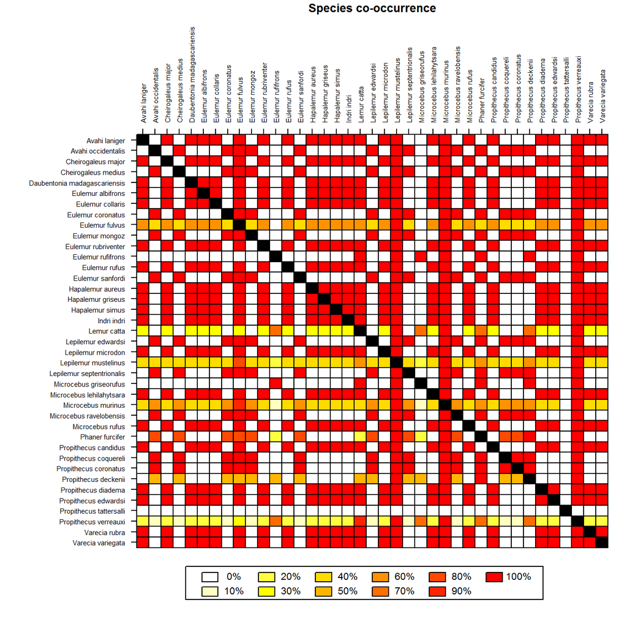

```r
outp <- SpGeoCod(lemurs, mdg_biomes, areanames = "name")

coex <- CoExClass(outp)
plot(coex, plottype = "coexistence")
```

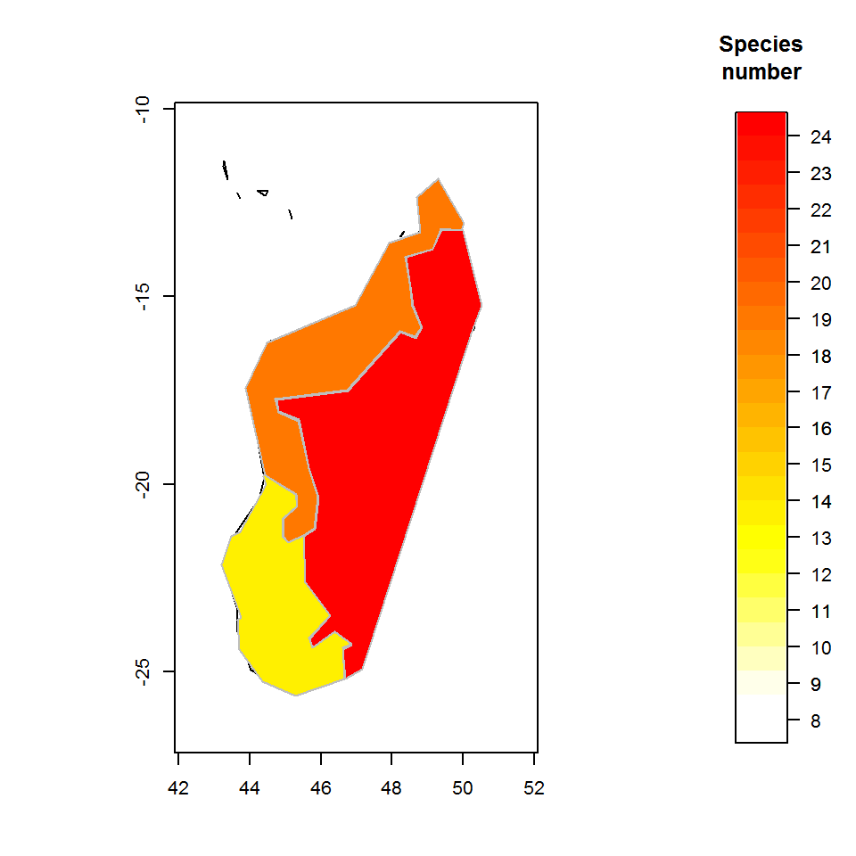

```
## class       : SpatialPolygonsDataFrame
## features    : 3
## extent      : 43.19906, 50.50903, -25.64502, -11.85583  (xmin, xmax, ymin, ymax)
## coord. ref. : NA
## variables   : 8
## names       : id,       name,       name, id, ident.add, sp.count,      code, ord
## min values  :  1, Dry Forest, Dry Forest,  1,         1,        8, #FF0000FF,   1
## max values  :  3, Shrublands, Shrublands,  3,         3,       24, #FFF000FF,   3
```

```r
outp <- SpGeoCod(lemurs, mdg_biomes, areanames = "name")

MapRichness(outp, leg = "continuous", xlim = c(42,52), ylim = c(-27, -10))
```

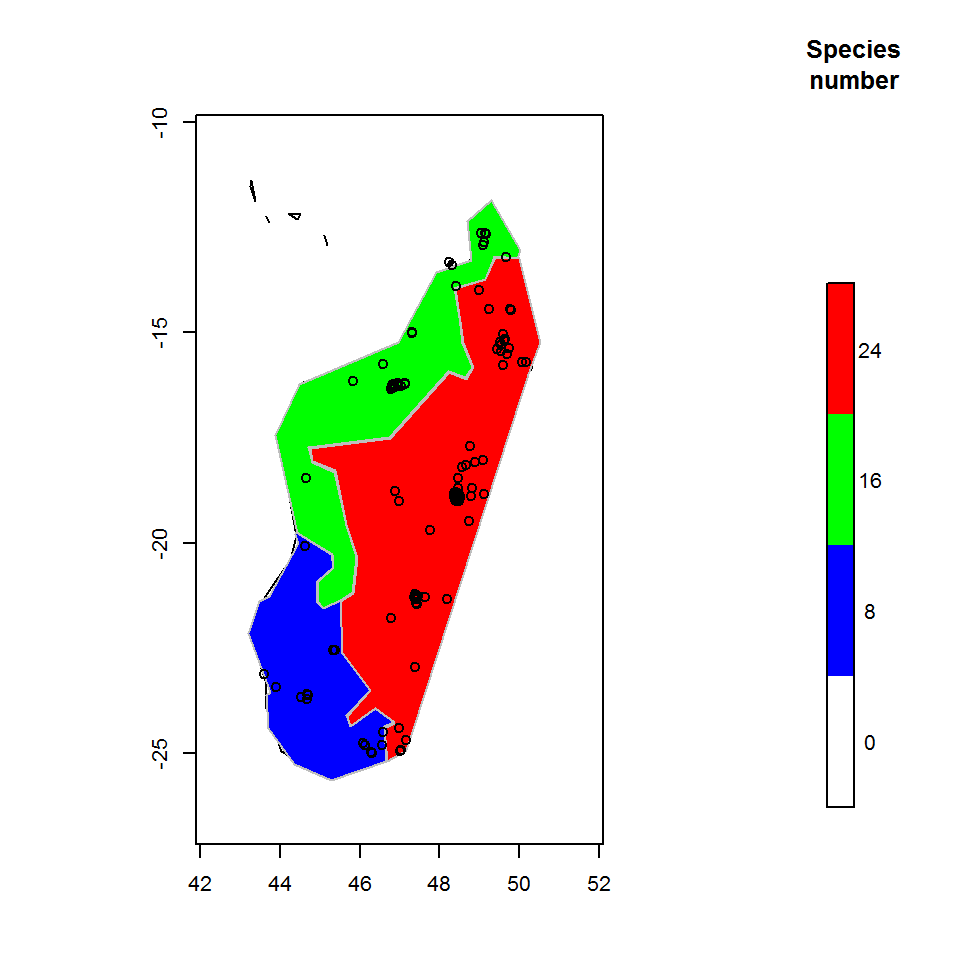

```
## class       : SpatialPolygonsDataFrame
## features    : 3
## extent      : 43.19906, 50.50903, -25.64502, -11.85583  (xmin, xmax, ymin, ymax)
## coord. ref. : NA
## variables   : 8
## names       : id,       name,       name, id, ident.add, sp.count,      code, ord
## min values  :  1, Dry Forest, Dry Forest,  1,         1,        8, #0000FFFF,   1
## max values  :  3, Shrublands, Shrublands,  3,         3,       24, #FF0000FF,   3
```

```r
MapRichness(outp, leg = "discrete", show.occ = T, xlim = c(42,52), ylim = c(-27, -10))
```

## Richness grids

Use `RichnessGrid` to produce a raster with species number per grid cell or the number of occurrences per grid cell, and `MapGrid` to visualize the grid in the geographic context.

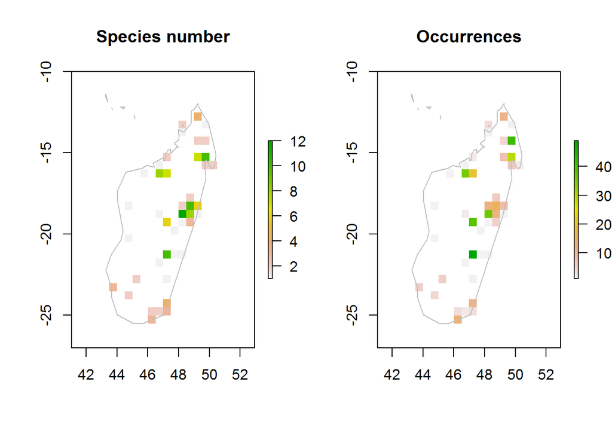

```r
data(lemurs)

limits <- extent(42, 52, -27, -10)
lemurs.spnum <- RichnessGrid(lemurs, limits, reso = 30, type = "spnum") #species number

lemurs.abu <- RichnessGrid(lemurs, limits,reso = 30, type = "abu") #occurrence number
par(mfrow = c(1,2))
MapGrid(lemurs.spnum)
title("Species number")

MapGrid(lemurs.abu)
title("Occurrences")
```

## Range size/Extent of occurrence

You can calculate species ranges and range size using the `CalcRange` function. This uses the occurrence points to calculate a convex hull polygon representing an estimate of the species range given the data. The `value` argument controls the output value, which can either be a data.frame of ranges sizes in square kilometres or a set of polygons showing the ranges.

```r
data(lemurs)
data(mdg_poly)

inp <- ReadPoints(lemurs, mdg_poly)

are <- CalcRange(data.frame(inp$identifier, inp$species_coordinates),
                value = "area")

head(are)
```

```
##                       EOO
## Avahi laniger       20777
## Avahi occidentalis    124
## Cheirogaleus major  48435
## Cheirogaleus medius   121
## Eulemur albifrons    1868
## Eulemur coronatus    1405
```

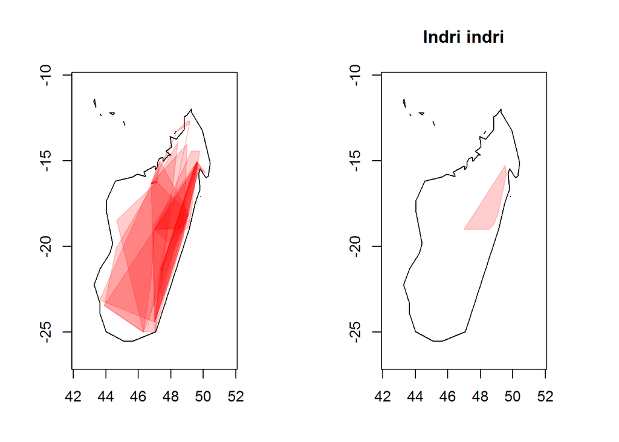

```r
shp <- CalcRange(data.frame(inp$identifier,
                     inp$species_coordinates), value = "shape")
par(mfrow = c(1,2))
PlotHull(shp, select = "all", xlim = c(42, 52), ylim = c(-27, -10))
PlotHull(shp, select = "Indri indri", xlim = c(42, 52), ylim = c(-27, -10))
```

## Species richness from ranges

Estimates based on range polygons instead of point occurrences can give more adequate estimate of species richness, if occurrence data are scarce. The RangeRichness function can be used to calculate species richness based on range polygons. Here, we will use the polygons calculated from the point occurrences in the previous example.

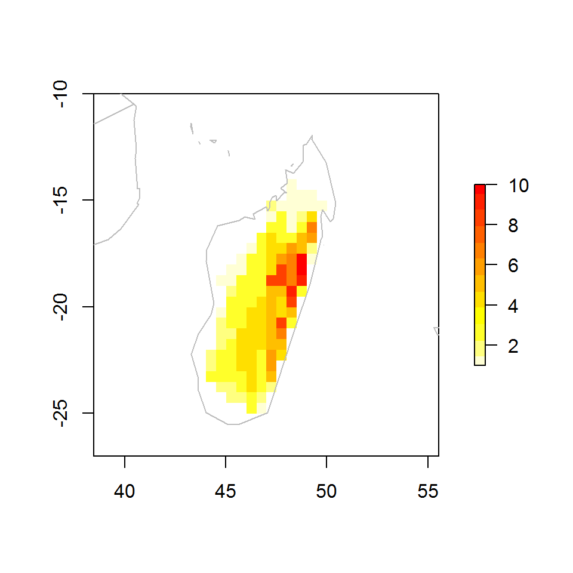

```r
bb <- RangeRichness(shp, limits = c(42, 52, -27, -10), reso = 30)
MapGrid(bb, col = rev(heat.colors(12)))
```

Literature

Becker, Richard A, Allan R Wilks, Ray Brownrigg, and Thomas P Minka. 2013. *maps: Draw Geographical Maps*. http://cran.r-project.org/package=maps.

Bivand, Roger S, Edzer Pebesma, and Virgilio Gomez-Rubio. 2013. *Applied spatial data analysis with R, Second edition*. Springer.

Bivand, Roger, and Nicholas Lewin-Koh. 2013. *maptools: Tools for reading and handling spatial objects*. http://cran.r-project.org/package=maptools.

Bivand, Roger, and Colin Rundel. 2014. *rgeos: Interface to Geometry Engine - Open Source (GEOS)*. http://cran.r-project.org/package=rgeos.

Crawley, M J. 2012. *The R book*. John Wiley; Sons.

Hijmans, Robert J. 2014. *Raster: Geographic data analysis and modeling*. http://cran.r-project.org/package=raster.

Olson, D M, E Dinerstein, E D Wikramanayake, N.l D Burgess, G V N Powell, E C Underwood, J A D’amico, et al. 2001. “Terrestrial Ecoregions of the World: A New Map of Life on Earth.” *BioScience* 51 (11): 933–38.

Pebesma, E J, and R S Bivand. 2005. *Classes and methods for spatial data in R*. http://cran.r-project.org/doc/Rnews/.

Töpel, M, M F Calio, A Zizka, R Scharn, D Silvestro, and A Antonelli. 2014. “SpeciesGeoCoder: Fast categorisation of species occurrences for analyses of biodiversity, biogeography, ecology and evolution.” *BioRxiv*.

WWF. 2014. “WWF terrestrial ecoregions:” worldwildlife.org/publications/terrestrial-ecoregions-of-the-world.